# Archbold - *Crotalaria avonensis*

Supplement

2025-02-16

#### Authors:

Niklas Neisse (neisse.n@protonmail.com), Aspen Workman, Diāna Spurīte, **Aldo Compagnoni** (aldo.compagnoni@idiv.de)

# Chapter I - Data handeling

## Introducion

This supplementary material relates to the *Crotalaria avonensis* dataset from Archbold Biological Station.

The GIS and Data Management program at [Archbold Biological Station](https://www.archbold-station.org/gis-and-data-mgmt/) maintains a comprehensive collection of ecological and environmental data gathered through various research initiatives and ongoing long-term monitoring projects. One key platform for accessing this data is the Archbold Biological Station’ [Ecological Data Inventory (EDI)](https://portal.edirepository.org/nis/home.jsp), which hosts extensive datasets related to biodiversity, land cover, climate, and ecological patterns.

For our model, we utilized 20 years of demographic data on the endangered legume [*Crotalaria avonensis*](https://portal.edirepository.org/nis/mapbrowse?packageid=edi.219.1) using an Integrated Population Model (IPM). This dataset has previously been used in the work of [Menges et al. 2016](https://bioone.org/journals/southeastern-naturalist/volume-15/issue-3/058.015.0318/Ecology-and-Conservation-of-the-Endangered-Legume-Crotalaria-avonensis-in/10.1656/058.015.0318.short).

#### Setup

We use the following packages: `tidyverse`, `patchwork`, `skimr`, `ipmr`, `binom`, `bbmle`, `gridExtra`, `lme4`

## Data

This dataset provides demographic information from a long-term study of *Crotalaria avonensis*, an endangered small perennial herbaceous legume native to the Lake Wales Ridge in central Florida. The [study](https://portal.edirepository.org/nis/metadataviewer?packageid=edi.219.1) spans from 1998 to 2017 and monthly during the growing season tracks individual plant survival, size, and reproduction, recorded within permanent quadrats - 25 cm radius circles in stratified random positions within subjectively located belt transects. Additionally, the dataset contains information on fires, herbivory reduction through caging, and other events that might be of effect. Individuals were defined as groups of stems separated by 5 cm or more and marked with plastic toothpicks. Transplant data suggests this species has clonal growth.

```r
df <- read_csv(file.path(dir_data, 'crotalaria_avonensis_data.csv')) %>%
  janitor::clean_names() %>%
  mutate(across(c(5, 6, 11:length(.)), ~ na_if(., 9999))) %>%
  mutate(
    plant_id = paste(site, quad, plant, sep = "_"),
    year     = substr(date, 1, 4),
    month    = substr(date, 6, 7)) %>%
  arrange(site, quad, plant, year, month)

df_meta <- data.frame(variable = colnames(df)) %>%
  mutate(definition = c(
    'study site', 'quadrat number', 'macroplot number',
    'plant number (within quad)', 'direction within circular quad',
    'distance from quad center',    'was quad caged from 2012 onward',
    'vegetation type', 'year quadrat was initiated',
    'year-month of observation',    'fire severity Dec. 2014 or Jan. 2015',
    'fire severity Aug. 2005',  'fire severity May/June 2009',
    "fire severity B's ridge 2016", 'fire severity Feb. 2017',
    'fire severity Oct. 2017', 'survival code for month', 'number of stems',
    'number of branch tips', 'number of flowers (corolla showing)',
    'number of developing fruits', 'number of mature fruits', 'herbivory code',
    'plant identification', 'sample year', 'sample month'))
```

**Expand to skim the raw dataframe**

```r
skimr::skim(df)
```

Data summary

| Name | df |
| --- | --- |
| Number of rows | 86165 |
| Number of columns | 26 |
| _______________________ |  |
| Column type frequency: |  |
| character | 4 |
| numeric | 22 |
| ________________________ |  |
| Group variables | None |

**Variable type: character**

| skim_variable | n_missing | complete_rate | min | max | empty | n_unique | whitespace |
| --- | --- | --- | --- | --- | --- | --- | --- |
| date | 0 | 1 | 7 | 7 | 0 | 95 | 0 |
| plant_id | 0 | 1 | 5 | 12 | 0 | 906 | 0 |
| year | 0 | 1 | 4 | 4 | 0 | 19 | 0 |
| month | 0 | 1 | 2 | 2 | 0 | 8 | 0 |

**Variable type: numeric**

| skim_variable | n_missing | complete_rate | mean | sd | p0 | p25 | p50 | p75 | p100 | hist |
| --- | --- | --- | --- | --- | --- | --- | --- | --- | --- | --- |
| site | 0 | 1.00 | 6.80 | 4.98 | 1 | 1 | 6 | 12 | 18 | ▇▂▃▅▁ |
| quad | 0 | 1.00 | 53.32 | 45.87 | 1 | 12 | 48 | 86 | 204 | ▇▅▃▁▁ |
| mp | 0 | 1.00 | 9.91 | 6.74 | 1 | 3 | 10 | 16 | 22 | ▇▅▅▃▅ |
| plant | 0 | 1.00 | 79.00 | 792.23 | 1 | 3 | 7 | 14 | 16102 | ▇▁▁▁▁ |
| bearing | 1425 | 0.98 | 178.26 | 103.27 | 0 | 90 | 180 | 270 | 360 | ▇▇▇▇▇ |
| distance | 1330 | 0.98 | 16.29 | 6.85 | 0 | 11 | 17 | 22 | 52 | ▅▇▆▁▁ |
| caged | 0 | 1.00 | 0.36 | 0.48 | 0 | 0 | 0 | 1 | 1 | ▇▁▁▁▅ |
| veg | 0 | 1.00 | 1.85 | 0.85 | 1 | 1 | 2 | 3 | 3 | ▇▁▅▁▅ |
| quadyr | 0 | 1.00 | 2000.55 | 2.82 | 1998 | 1998 | 2001 | 2002 | 2009 | ▇▆▁▂▁ |
| burn_a | 86140 | 0.00 | 2.60 | 0.50 | 2 | 2 | 3 | 3 | 3 | ▅▁▁▁▇ |
| burn_b | 85411 | 0.01 | 0.49 | 0.93 | 0 | 0 | 0 | 0 | 3 | ▇▁▁▂▁ |
| burn_c | 85320 | 0.01 | 0.27 | 0.83 | 0 | 0 | 0 | 0 | 4 | ▇▁▁▁▁ |
| burn_d | 86146 | 0.00 | 0.79 | 0.92 | 0 | 0 | 1 | 1 | 3 | ▇▅▁▂▁ |
| burn_e | 86149 | 0.00 | 0.81 | 0.98 | 0 | 0 | 0 | 2 | 2 | ▇▁▁▁▅ |
| burn_f | 85274 | 0.01 | 0.03 | 0.20 | 0 | 0 | 0 | 0 | 2 | ▇▁▁▁▁ |
| s | 41528 | 0.52 | 0.39 | 0.61 | 0 | 0 | 0 | 1 | 6 | ▇▁▁▁▁ |
| st | 70291 | 0.18 | 2.28 | 2.09 | 1 | 1 | 2 | 3 | 33 | ▇▁▁▁▁ |
| br | 70293 | 0.18 | 4.22 | 5.39 | 0 | 1 | 2 | 5 | 85 | ▇▁▁▁▁ |
| fl | 70283 | 0.18 | 0.25 | 1.30 | 0 | 0 | 0 | 0 | 43 | ▇▁▁▁▁ |
| dv | 70449 | 0.18 | 0.04 | 0.47 | 0 | 0 | 0 | 0 | 30 | ▇▁▁▁▁ |
| fr | 70449 | 0.18 | 0.02 | 0.26 | 0 | 0 | 0 | 0 | 15 | ▇▁▁▁▁ |
| h | 70093 | 0.19 | 0.16 | 0.56 | 0 | 0 | 0 | 0 | 6 | ▇▁▁▁▁ |

## Data exploration

Each year recorded in the dataset includes multiple months of observations per individual. For the purpose of modeling population dynamics, we condensed the data to provide a single observation per individual for size, recruits, survival, flowering, fruiting, and fire exposure for each year. The data were condensed as follows:

1. Size was measured as the number of branch tips, and following the recommendations of Menges et al. (2016), we focused on the maximum size observed in each year.
2. & 3. Recruits and survival were recorded as binary variables, indicating whether the event occurred in a given year.

**The treatment of flowering, fruiting, and fire exposure is still undecided as of** *March 19, 2025*.

```r
df_mean_og <- df %>%
  filter(s < 6 | is.na(s)) %>%
  group_by(site, quad, plant, plant_id, year) %>%
  summarise(
    survives = if_else(all(is.na(s )), NA_real_, max(s,  na.rm = TRUE)),
    size_t0 =  if_else(all(is.na(br)), NA_real_, max(br, na.rm = TRUE)),
    .groups = "drop"
  ) %>%
  ungroup()
```

**Expand to skim the condenced raw dataframe**

```r
skimr::skim(df_mean_og)
```

Data summary

| Name | df_mean_og |
| --- | --- |
| Number of rows | 17214 |
| Number of columns | 7 |
| _______________________ |  |
| Column type frequency: |  |
| character | 2 |
| numeric | 5 |
| ________________________ |  |
| Group variables | None |

**Variable type: character**

| skim_variable | n_missing | complete_rate | min | max | empty | n_unique | whitespace |
| --- | --- | --- | --- | --- | --- | --- | --- |
| plant_id | 0 | 1 | 5 | 12 | 0 | 906 | 0 |
| year | 0 | 1 | 4 | 4 | 0 | 19 | 0 |

**Variable type: numeric**

| skim_variable | n_missing | complete_rate | mean | sd | p0 | p25 | p50 | p75 | p100 | hist |
| --- | --- | --- | --- | --- | --- | --- | --- | --- | --- | --- |
| site | 0 | 1.00 | 6.80 | 4.98 | 1 | 1 | 6 | 12 | 18 | ▇▂▃▅▁ |
| quad | 0 | 1.00 | 53.28 | 45.88 | 1 | 12 | 48 | 86 | 204 | ▇▅▃▁▁ |
| plant | 0 | 1.00 | 79.08 | 792.68 | 1 | 3 | 7 | 14 | 16102 | ▇▁▁▁▁ |
| survives | 7816 | 0.55 | 0.53 | 0.68 | 0 | 0 | 0 | 1 | 5 | ▇▁▁▁▁ |
| size_t0 | 12843 | 0.25 | 5.48 | 6.70 | 1 | 2 | 3 | 7 | 85 | ▇▁▁▁▁ |

### Work dataframe/ adjustments

Disclaimer: As of March 2025, we have not been in contact with the corresponding author.

During our exploration of the dataset, we found that the survival variable was coded as a factor. In addition to the obvious values indicating survival (1) and non-survival (0), dataset includes values that we interpret as follows: birth (3), birth after fire exposure (5), and missing observations (6). We excluded the missing observations (6) from the dataset entirely. For the **survival** variable, we re-coded the birth entries (3 and 5), assigning a survival value of 1 if the individual survived and 0 if the individual did not survive.

The species is known to exhibit dormancy, and this is reflected in the dataset. The longest dormancy period recorded was 3 years. We included **dormancy** as a new variable in the dataset. However, it is important to note that for a 3-year period close to the beginning or end of the records, we cannot be certain of an individuals true birth or death. In these cases, the dormancy, survival, and birth variables were marked as NA.

Additionally, we included the **size of individuals in the subsequent** year as a variable. In cases where dormancy was recorded, the size variable was marked as NA. Upon the conclusion of dormancy, the individual’s size was recorded for the following year.

For individuals whose true birth could be determined (i.e., those born at least 4 years after the start of the records), we classified them as **recruits** and included an **age** variable, which increased through periods of dormancy.

```r
df_mean <- df_mean_og %>%
  group_by(site, quad, plant, plant_id) %>%
  mutate(
    # Handle survival based on previous dormancy status
    survives = if_else(
      # If the current status is dead or NA
      (survives == 0 | is.na(survives)) &
        # Check if survived in the previous 1, 2, or 3 years
        (lag(survives, 1) == 1 | lag(survives, 2) == 1 | lag(survives, 3) == 1) &
        # Check if survives in the next 1, 2, or 3 years
        (lead(survives, 1) == 1 | lead(survives, 2) == 1 | lead(survives, 3) == 1),
      1,
      survives
    ),

    # Set survival to 0 if plant dies after 3 consecutive years of dormancy
    survives = if_else(
      survives == 1 &
        lead(survives, 1) == 0 &
        lead(survives, 2) == 0 &
        lead(survives, 3) == 0,
      0,
      survives
    )
  ) %>%

  # Define dormancy
  mutate(
    dormancy = case_when(
      survives == 1 & is.na(size_t0) ~ 1,
      size_t0  >  0                  ~ 0,
      TRUE ~ NA_real_
    )
  ) %>%

  # Define recruits
  mutate(
    recruit = case_when(
      (survives == 3 | survives == 5) ~ 1,
      TRUE ~ NA_real_
    )
  ) %>%

  mutate(
    # Make sure that no survival value exceeds 1
    survives = if_else(survives > 1, 1, survives),

    # Handle missing size_t0 for dead plants by setting NA in survival column
    survives = if_else(survives == 0 & is.na(size_t0), NA, survives)
  ) %>%

  ungroup() %>%
  arrange(site, quad, plant, year) %>%
  group_by(site, quad, plant, plant_id) %>%

  # Set size_t1 based on survival; propagate size_t0 if survives, otherwise set to NA
  mutate(
    size_t1 = case_when(
      survives == 1 ~ lead(size_t0),
      TRUE ~ NA_real_
    )
  ) %>%

  ungroup() %>%

  # Compute log-transformed sizes and their powers for modeling
  mutate(
    logsize_t0   = log(size_t0),
    logsize_t1   = log(size_t1),
    logsize_t0_2 = logsize_t0^2,
    logsize_t0_3 = logsize_t0^3
  ) %>%
  group_by(site, quad, plant, plant_id) %>%
  mutate(age = NA_real_) %>%  # Initialize age as NA for all

  # Apply for loop to calculate age
  mutate(age = {
    # Initialize age vector
    age_vector <- rep(NA_real_, n())

    # Iterate over each row in the group (each site, quad, and plant combination)
    for (i in 1:n()) {
      if (!is.na(recruit[i]) && recruit[i] == 1) {
        age_vector[i] <- 1  # Set age to 1 for recruits
      } else if (!is.na(dormancy[i]) && dormancy[i] >= 0) {
        # If plant survives, increment the age based on previous value
        if (i > 1 && !is.na(age_vector[i - 1])) {
          age_vector[i] <- age_vector[i - 1] + 1
        }
      }
    }

    # Return the computed age vector
    age_vector
  }) %>%

  ungroup()
```

**Expand to skim the working dataframe**

```r
skimr::skim(df_mean)
```

Data summary

| Name | df_mean |
| --- | --- |
| Number of rows | 17214 |
| Number of columns | 15 |
| _______________________ |  |
| Column type frequency: |  |
| character | 2 |
| numeric | 13 |
| ________________________ |  |
| Group variables | None |

**Variable type: character**

| skim_variable | n_missing | complete_rate | min | max | empty | n_unique | whitespace |
| --- | --- | --- | --- | --- | --- | --- | --- |
| plant_id | 0 | 1 | 5 | 12 | 0 | 906 | 0 |
| year | 0 | 1 | 4 | 4 | 0 | 19 | 0 |

**Variable type: numeric**

| skim_variable | n_missing | complete_rate | mean | sd | p0 | p25 | p50 | p75 | p100 | hist |
| --- | --- | --- | --- | --- | --- | --- | --- | --- | --- | --- |
| site | 0 | 1.00 | 6.80 | 4.98 | 1 | 1.00 | 6.00 | 12.00 | 18.00 | ▇▂▃▅▁ |
| quad | 0 | 1.00 | 53.28 | 45.88 | 1 | 12.00 | 48.00 | 86.00 | 204.00 | ▇▅▃▁▁ |
| plant | 0 | 1.00 | 79.08 | 792.68 | 1 | 3.00 | 7.00 | 14.00 | 16102.00 | ▇▁▁▁▁ |
| survives | 13115 | 0.24 | 0.91 | 0.29 | 0 | 1.00 | 1.00 | 1.00 | 1.00 | ▁▁▁▁▇ |
| size_t0 | 12843 | 0.25 | 5.48 | 6.70 | 1 | 2.00 | 3.00 | 7.00 | 85.00 | ▇▁▁▁▁ |
| dormancy | 12707 | 0.26 | 0.03 | 0.17 | 0 | 0.00 | 0.00 | 0.00 | 1.00 | ▇▁▁▁▁ |
| recruit | 16935 | 0.02 | 1.00 | 0.00 | 1 | 1.00 | 1.00 | 1.00 | 1.00 | ▁▁▇▁▁ |
| size_t1 | 13723 | 0.20 | 5.96 | 7.02 | 1 | 2.00 | 4.00 | 7.00 | 85.00 | ▇▁▁▁▁ |
| logsize_t0 | 12843 | 0.25 | 1.22 | 0.95 | 0 | 0.69 | 1.10 | 1.95 | 4.44 | ▇▆▅▁▁ |
| logsize_t1 | 13723 | 0.20 | 1.32 | 0.94 | 0 | 0.69 | 1.39 | 1.95 | 4.44 | ▇▇▆▂▁ |
| logsize_t0_2 | 12843 | 0.25 | 2.39 | 2.84 | 0 | 0.48 | 1.21 | 3.79 | 19.74 | ▇▂▁▁▁ |
| logsize_t0_3 | 12843 | 0.25 | 5.43 | 9.07 | 0 | 0.33 | 1.33 | 7.37 | 87.69 | ▇▁▁▁▁ |
| age | 16320 | 0.05 | 2.94 | 2.03 | 1 | 1.00 | 2.00 | 4.00 | 12.00 | ▇▂▁▁▁ |

# Chapter II - Investigations

## Introduction

We will now investigate several key aspects of the data to maximize its utility, given the constraints. Specifically, we aim to address the following questions:

1. How does the size of recruits develop over time?
2. What is the size trajectory following the exit from dormancy?
3. Is it possible to distinguish between true recruits and individuals exiting dormancy when their first appearance coincides with the beginning of the observation period?

## Issue 1. - Size of recruits

To understand how the plants develop over time, we first examine the size at their first appearance. We can confidently identify this as their first appearance only if there is a record of three consecutive years with no presence prior to that year.

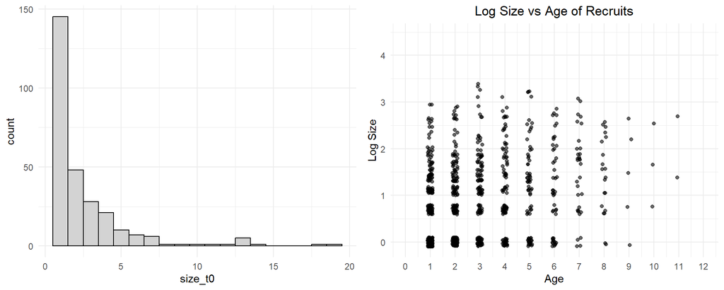

```r
i1_hist <- ggplot(df_mean %>% filter(recruit == 1), aes(x = size_t0)) +
  geom_histogram(binwidth = 1, fill = "lightgray", color = "black") +
  theme_minimal()

i1_size_age <- ggplot(df_mean, aes(x = age, y = logsize_t0)) +
  geom_jitter(width = 0.1, height = 0.1, alpha = 0.6) +
  theme_minimal() +
  labs(x = "Age", y = "Log Size", title = "Log Size vs Age of Recruits") +
  theme(plot.title = element_text(hjust = 0.5)) +
  scale_x_continuous(
    limits = c(0, 12),
    breaks = seq(0, 12, by = 1))


# Combine the plots
grid.arrange(i1_hist, i1_size_age,
             ncol = 2)
```

## Issue 2 - Size after Dormancy

This plot shows the distribution of size_t1 for dormant individuals.

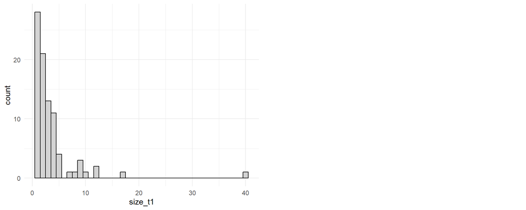

```r
i2_hist <- ggplot(df_mean %>% filter(dormancy == 1), aes(x = size_t1)) +
  geom_histogram(binwidth = 1, fill = "lightgray", color = "black") +
  theme_minimal()



# Combine the plots
grid.arrange(i2_hist,
             ncol = 2)
```

## Issue 3

To facilitate direct comparison of observations, we create a new data frame that flags entries based on two criteria. First, individuals with missing size_t0 values for the years 1999, 2000, or 2001 are flagged. Second, individuals with non-missing size_t1 values for any of these years (1999, 2000, or 2001) are also flagged. After applying these flags, we assign an age to each individual.

```r
df_mean_f <- df_mean %>%
  group_by(site, quad, plant, plant_id) %>%
  mutate(
    flag_1 = if_else(
      any(year == 1999 & is.na(size_t0)) |
        (any(year %in% c(1999, 2000)) & all(is.na(size_t0[year %in% c(1999, 2000)]))) |
        (any(year %in% c(1999, 2000, 2001)) & all(is.na(size_t0[year %in% c(1999, 2000, 2001)]))),
      1, 0
    ),
    flag_2 = if_else(any(year %in% c(1999, 2000, 2001) & !is.na(size_t1)), 1, 0)
  ) %>%
  ungroup() %>%
  filter(flag_1 == 1 & flag_2 == 1)

# Initialize the age column
df_mean_f$age <- NA

# Loop through each unique combination of site, quad, and plant
for (i in 1:nrow(df_mean_f)) {

  current_site <- df_mean_f$site[i]
  current_quad <- df_mean_f$quad[i]
  current_plant <- df_mean_f$plant[i]

  # Subset the data for the current combination of site, quad, and plant
  group_data <- df_mean_f %>%
    filter(site == current_site, quad == current_quad, plant == current_plant) %>%
    arrange(year)  # Ensure the rows are ordered by year

  # Initialize the current age starting at NA
  current_age <- 1  # We will start at 1 when the first non-NA size_t0 is found

  # Loop through the rows within this group
  for (j in 1:nrow(group_data)) {
    if (!is.na(group_data$size_t0[j])) {
      # If the size_t0 is not NA, assign the current age
      df_mean_f$age[df_mean_f$site == current_site &
                      df_mean_f$quad == current_quad &
                      df_mean_f$plant == current_plant &
                      df_mean_f$year == group_data$year[j]] <- current_age
      # Increment the age for the next year
      current_age <- current_age + 1
    } else if (j > 1) {
      # If size_t0 is NA, carry the age from the previous row
      previous_year_age <- df_mean_f$age[df_mean_f$site == current_site &
                                           df_mean_f$quad == current_quad &
                                           df_mean_f$plant == current_plant &
                                           df_mean_f$year == group_data$year[j - 1]]
      df_mean_f$age[df_mean_f$site == current_site &
                      df_mean_f$quad == current_quad &
                      df_mean_f$plant == current_plant &
                      df_mean_f$year == group_data$year[j]] <- previous_year_age
    }
  }
}
```

The following plots display key patterns in the data: 1. Histogram of Size at t0 showing the distribution of size_t0 for plants at age 1, with bins of width 1. 2. Scatter Plot of Log Size at t0 vs Age visualizing the relationship between age and log size.

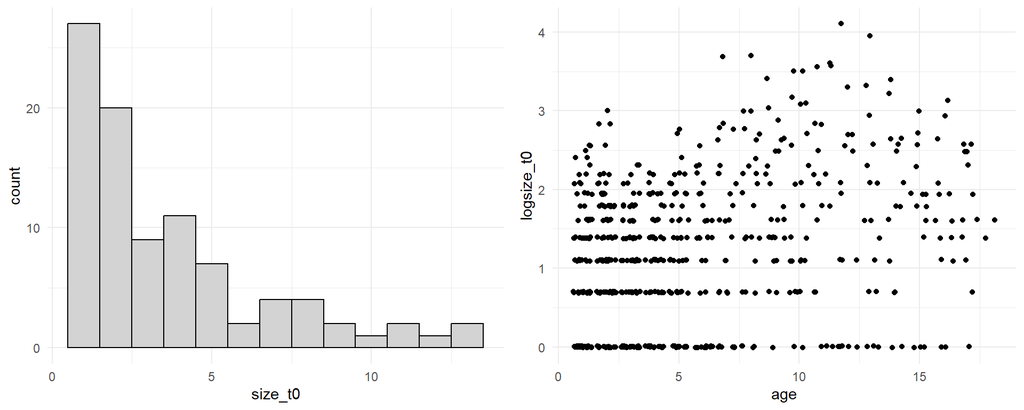

```r
i3_hist <- ggplot(df_mean_f %>% filter(age == 1), aes(x = size_t0)) +
  geom_histogram(binwidth = 1, fill = "lightgray", color = "black") +
  theme_minimal()

i3_size_age <- ggplot() +
  geom_jitter(
    data = df_mean_f,
    aes(x = age, y = logsize_t0)) +
  theme_minimal()


# Combine the plots
grid.arrange(i3_hist, i3_size_age,
             ncol = 2)
```

In this section, we fit four different linear mixed models to examine the relationship between age and log size at time zero (logsize_t0), incorporating random effects to account for variability among individual plant IDs.

1. Linear Model: The first model uses a linear relationship between age and log size, with a random intercept for plant-id.
2. Quadratic Model: The second model introduces a quadratic term for log size to capture potential non-linear effects of age on log size
3. Linear Model with Age: The third model reverses the dependent and independent variables, modeling log size as a function of age, with a random intercept for plant-id.
4. Quadratic Model with Age: The fourth model extends the third model by including a quadratic term for age.

```r
# Fit the first model: logsize_t0 ~ age + (1 | plant_id) (linear model)
mod_flag_linear <- lmer(age ~ logsize_t0 + (1 | plant_id), data = df_mean_f)
#summary(mod_flag_linear)

# Predict values using the linear model
df_mean_f$predicted_linear <- predict(mod_flag_linear, newdata = df_mean_f, re.form = NULL)

# Fit the second model: logsize_t0 ~ age + I(age^2) + (1 | plant_id) (quadratic model)
mod_flag_quad <- lmer(age ~ logsize_t0 + I(logsize_t0^2) + (1 | plant_id), data = df_mean_f)
#summary(mod_flag_quad)

# Predict values using the quadratic model
df_mean_f$predicted_quad <- predict(mod_flag_quad, newdata = df_mean_f, re.form = NULL)

# Fit the third model: logsize_t0 ~ age + (1 | plant_id) (reversed model)
mod_flag_logsize_age <- lmer(logsize_t0 ~ age + (1 | plant_id), data = df_mean_f)
#summary(mod_flag_logsize_age)

# Predict values using the logsize_t0 ~ age model
df_mean_f$predicted_logsize_age <- predict(mod_flag_logsize_age, newdata = df_mean_f, re.form = NULL)

# Fit the fourth model: logsize_t0 ~ age + I(age^2) + (1 | plant_id) (quadratic term for age)
mod_flag_quad_age <- lmer(logsize_t0 ~ age + I(age^2) + (1 | plant_id), data = df_mean_f)
#summary(mod_flag_quad_age)

# Predict values using the logsize_t0 ~ age + I(age^2) model
df_mean_f$predicted_quad_age <- predict(mod_flag_quad_age, newdata = df_mean_f, re.form = NULL)
```

The following plots visualize the relationships captured by the second, third, and fourth models

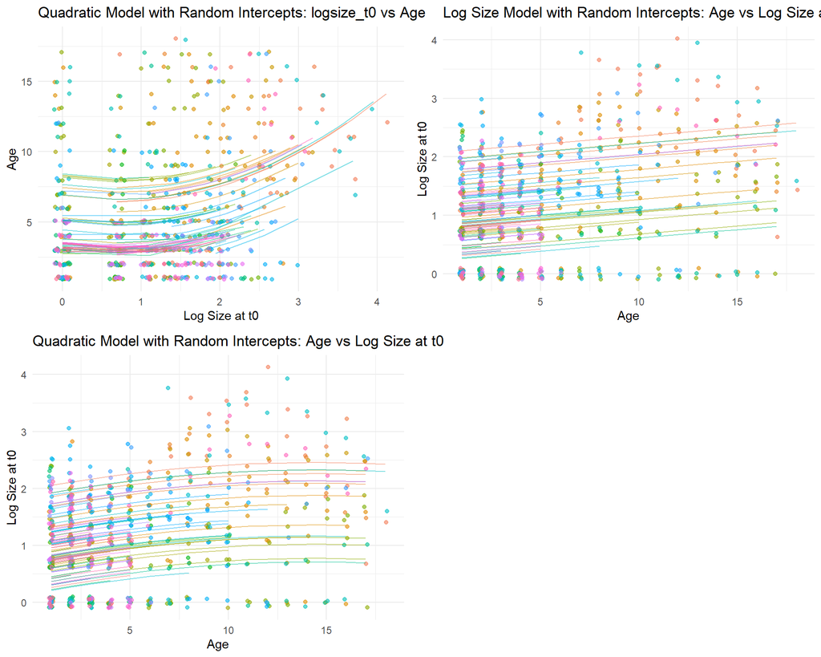

```r
# Plot the second model (quadratic relationship for logsize_t0 ~ logsize_t0^2)
p_i3_mod_1 <- ggplot(df_mean_f, aes(x = logsize_t0, y = age)) +
  geom_jitter(aes(color = plant_id), width = 0.1, height = 0.1, alpha = 0.6) +
  geom_line(aes(y = predicted_quad, color = plant_id), alpha = 0.5) +
  theme_minimal() +
  labs(title = "Quadratic Model with Random Intercepts: logsize_t0 vs Age",
       y = "Age",
       x = "Log Size at t0") +
  theme(legend.position = "none")

# Plot the third model (logsize_t0 ~ age relationship)
p_i3_mod_2 <- ggplot(df_mean_f, aes(x = age, y = logsize_t0)) +
  geom_jitter(aes(color = plant_id), width = 0.1, height = 0.1, alpha = 0.6) +
  geom_line(aes(y = predicted_logsize_age, color = plant_id), alpha = 0.5) +
  theme_minimal() +
  labs(title = "Log Size Model with Random Intercepts: Age vs Log Size at t0",
       y = "Log Size at t0",
       x = "Age") +
  theme(legend.position = "none")

# Plot the fourth model (logsize_t0 ~ age + I(age^2) relationship)
p_i3_mod_3 <- ggplot(df_mean_f, aes(x = age, y = logsize_t0)) +
  geom_jitter(aes(color = plant_id), width = 0.1, height = 0.1, alpha = 0.6) +
  geom_line(aes(y = predicted_quad_age, color = plant_id), alpha = 0.5) +
  theme_minimal() +
  labs(title = "Quadratic Model with Random Intercepts: Age vs Log Size at t0",
       y = "Log Size at t0",
       x = "Age") +
  theme(legend.position = "none")

grid.arrange(p_i3_mod_1, p_i3_mod_2,
             p_i3_mod_3,
             ncol = 2)
```

# Chapter III - BUGS

Unfortunately we have the following bugs:

1. The survival variable seems to fail for some observations.

**Expand to see the bug-dataframe**

```r
df_issue <- df_mean[c(932:950,
                      1397:1406,
                      1418:1425,
                      1749:1759,
                      1768:1778,
                      2461:2470,
                      2902:2907,
                      3003:3019,
                      3432:3438,
                      3906:3912),]

print(df_issue[, 4:10], n = 50)
```

```
## # A tibble: 106 × 7
##    plant_id year  survives size_t0 dormancy recruit size_t1
##    <chr>    <chr>    <dbl>   <dbl>    <dbl>   <dbl>   <dbl>
##  1 1_2_8    1999         1       1        0      NA      NA
##  2 1_2_8    2000        NA      NA       NA      NA      NA
##  3 1_2_8    2001         1      NA        1      NA      NA
##  4 1_2_8    2002         1      NA        1      NA      NA
##  5 1_2_8    2003        NA      NA       NA      NA      NA
##  6 1_2_8    2004         1       1        0      NA       1
##  7 1_2_8    2005         1       1        0      NA       2
##  8 1_2_8    2006         1       2        0      NA       2
##  9 1_2_8    2007         1       2        0      NA       2
## 10 1_2_8    2008         1       2        0      NA       3
## 11 1_2_8    2009         1       3        0      NA       3
## 12 1_2_8    2010         1       3        0      NA      NA
```

[output cut: 39 more lines]

# Literature

1. **Menges**, E. S., Pace-Aldana, B., Haller, S. J., & Smith, S. A. (**2016**). Ecology and conservation of the endangered legume Crotalaria avonensis in Florida scrub. Southeastern Naturalist, 15(3), 549-574. (https://bioone.org/journals/southeastern-naturalist/volume-15/issue-3/058.015.0318/Ecology-and-Conservation-of-the-Endangered-Legume-Crotalaria-avonensis-in/10.1656/058.015.0318.short; accessed: 2025, Mar. 19)